# MPulleyM2Q2

Melissa Pulley

2024-04-22

1. Come up with a biological example of data that has a binomial distribution. Your example MUST be based on a scientific paper. You need to add the citation of the paper that you based your distribution on! Remember, you need an n and a p.

   WOODHAMS, DOUGLAS C., and ROSS A. ALFORD. “Ecology of Chytridiomycosis in Rainforest Stream Frog Assemblages of Tropical Queensland.” Conservation biology 19.5 (2005): 1449–1459. Web.
2. Calculate and plot the PMF for all potential results.

```r
n=765
x = 0:n
p = 0.1

my_pmf = dbinom(x,n,p)
sum(my_pmf)
```

```
## [1] 1
```

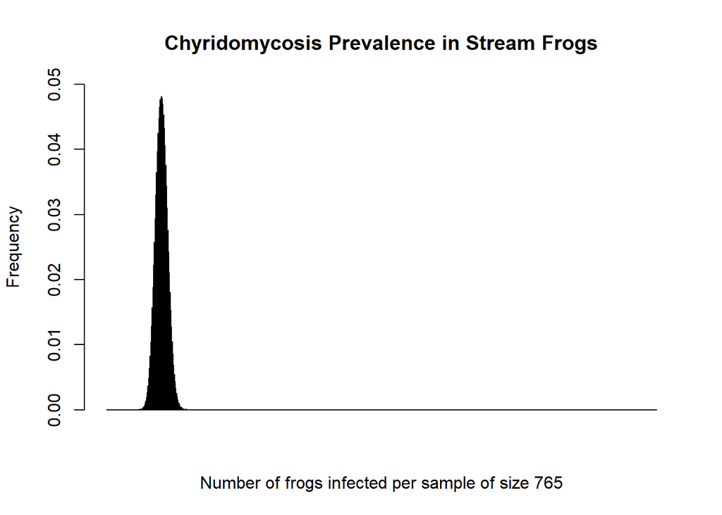

```r
newplot<-barplot(my_pmf, col = "steelblue", ylim=c(0,0.05), main="Chyridomycosis Prevalence in Stream Frogs", xlab="Number of frogs infected per sample of size 765", ylab = "Frequency")
```

3. Calculate the expected value.

The expected value is 76.5.

```r
EV<-sum(my_pmf*x)
EV
```

```
## [1] 76.5
```

4. Based on your biologically example, simulate a single study, and calculate the maximum likelihood estimate.

The estimated MLE is 0.1098039.

```r
set.seed(43)
sims1 = rbinom(n,1,p)
MLE = sum(sims1)/n
MLE
```

```
## [1] 0.1098039
```

5. Come up with a biological example of data that has a Poisson distribution. Your example MUST be based on a scientific paper. You need to add the citation of the paper that you based your distribution on! Calculate and plot the PMF

This paper estimates number of aphids on a potato plant. The mean number of aphids is 536.

Anscombe, F. J. “On Estimating the Population of Aphids in A Potato Field.” Annals of applied biology 35.4 (1948): 567–571. Web.

```r
n=536
x = 0:(2*n)
lambda =  536

pois_pmf = dpois(x,lambda)

sum(pois_pmf)
```

```
## [1] 1
```

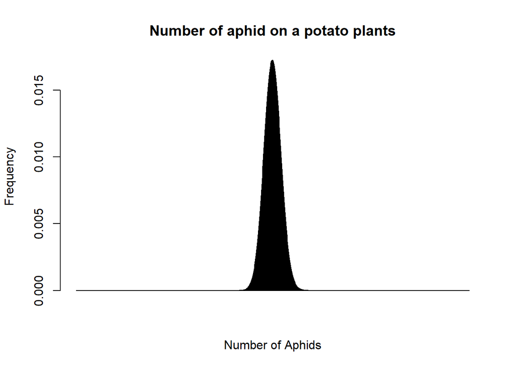

```r
newplot<-barplot(pois_pmf, col = "steelblue", main="Number of aphid on a potato plants", xlab="Number of Aphids", ylab = "Frequency")
```